# Máster en Big Data. Fundamentos matemáticos del análisis de datos.

Proyecto Final.

Jorge Rivera Rueda

Curso 2020-21.

## Introducción

En este proyecto se va a hacer una exploración y análisis de un conjunto de datos descargado desde Kaggle. El conjunto de datos que se va a utilizar es un csv que contiene información sobre los vuelos realizados en Estados Unidos en enero de 2019. El dataset comprende información de todos los vuelos realizados por las diferentes compañías aéreas desde el 1 de enero hasta el 31 del mismo mes y para todos los aeropuertos del país.

El enlace donde se puede encontrar el dataset en Kaggle es: https://www.kaggle.com/divyansh22/flight-delay-prediction?select=Jan_2019_ontime.csv

## Carga de librerías

A continuación es necesario cargar las librerías que se necesitan para hacer la exploración y poder leer el conjunto de datos:

```r
library(tidyverse)
```

```r
library(ggplot2)
library(DataExplorer)
library(maps)
```

- La librería tidyverse es necesaria para poder leer el fichero csv y más cosas.
- La librería ggplot2 se va a utilizar para hacer diferentes representaciones y análisis del conjunto de datos para buscar relaciones y hacer comparaciones entre las variables.
- La librería DataExplorer nos permitirá obtener una primera exploración de los datos y ver la normalidad de los mismos entre otras cosas.
- La librería maps permite representar regiones mediante un mapa y será muy útil para hacernos una idea de la localización de los aeropuertos desde los que salieron y a los que llegaron los diferentes vuelos.

## Leer el fichero que contiene el dataset

El siguiente paso es leer el dataset, que en mi caso es un archivo csv:

```r
vuelos = read_csv("Data/Jan_2019_ontime.csv")
```

## Exploración inicial de los datos

Lo primero que hay que hacer es conocer cómo es el dataset, qué dimensiones tiene, cuántas variables y observaciones hay, de qué tipo es cada una de las variables…

```r
dim(vuelos)
```

```
## [1] 583985     22
```

El dataset tiene 583985 observaciones y 22 variables.

```r
str(vuelos)
```

```
## tibble [583,985 × 22] (S3: spec_tbl_df/tbl_df/tbl/data.frame)
##  $ DAY_OF_MONTH         : num [1:583985] 1 1 1 1 1 1 1 1 1 1 ...
##  $ DAY_OF_WEEK          : num [1:583985] 2 2 2 2 2 2 2 2 2 2 ...
##  $ OP_UNIQUE_CARRIER    : chr [1:583985] "9E" "9E" "9E" "9E" ...
##  $ OP_CARRIER_AIRLINE_ID: num [1:583985] 20363 20363 20363 20363 20363 ...
##  $ OP_CARRIER           : chr [1:583985] "9E" "9E" "9E" "9E" ...
##  $ TAIL_NUM             : chr [1:583985] "N8688C" "N348PQ" "N8896A" "N8886A" ...
##  $ OP_CARRIER_FL_NUM    : num [1:583985] 3280 3281 3282 3283 3284 ...
##  $ ORIGIN_AIRPORT_ID    : num [1:583985] 11953 13487 11433 15249 10397 ...
##  $ ORIGIN_AIRPORT_SEQ_ID: num [1:583985] 1195302 1348702 1143302 1524906 1039707 ...
##  $ ORIGIN               : chr [1:583985] "GNV" "MSP" "DTW" "TLH" ...
##  $ DEST_AIRPORT_ID      : num [1:583985] 10397 11193 11193 10397 11778 ...
##  $ DEST_AIRPORT_SEQ_ID  : num [1:583985] 1039707 1119302 1119302 1039707 1177801 ...
##  $ DEST                 : chr [1:583985] "ATL" "CVG" "CVG" "ATL" ...
##  $ DEP_TIME             : chr [1:583985] "0601" "1359" "1215" "1521" ...
##  $ DEP_DEL15            : num [1:583985] 0 0 0 0 0 0 0 0 0 0 ...
##  $ DEP_TIME_BLK         : chr [1:583985] "0600-0659" "1400-1459" "1200-1259" "1500-1559" ...
##  $ ARR_TIME             : chr [1:583985] "0722" "1633" "1329" "1625" ...
##  $ ARR_DEL15            : num [1:583985] 0 0 0 0 0 0 0 0 0 0 ...
##  $ CANCELLED            : num [1:583985] 0 0 0 0 0 0 0 0 0 0 ...
##  $ DIVERTED             : num [1:583985] 0 0 0 0 0 0 0 0 0 0 ...
##  $ DISTANCE             : num [1:583985] 300 596 229 223 579 574 341 585 833 533 ...
##  $ X22                  : logi [1:583985] NA NA NA NA NA NA ...
##  - attr(*, "spec")=
##   .. cols(
##   ..   DAY_OF_MONTH = col_double(),
##   ..   DAY_OF_WEEK = col_double(),
##   ..   OP_UNIQUE_CARRIER = col_character(),
##   ..   OP_CARRIER_AIRLINE_ID = col_double(),
##   ..   OP_CARRIER = col_character(),
##   ..   TAIL_NUM = col_character(),
##   ..   OP_CARRIER_FL_NUM = col_double(),
##   ..   ORIGIN_AIRPORT_ID = col_double(),
##   ..   ORIGIN_AIRPORT_SEQ_ID = col_double(),
##   ..   ORIGIN = col_character(),
##   ..   DEST_AIRPORT_ID = col_double(),
##   ..   DEST_AIRPORT_SEQ_ID = col_double(),
##   ..   DEST = col_character(),
##   ..   DEP_TIME = col_character(),
##   ..   DEP_DEL15 = col_double(),
##   ..   DEP_TIME_BLK = col_character(),
##   ..   ARR_TIME = col_character(),
##   ..   ARR_DEL15 = col_double(),
##   ..   CANCELLED = col_double(),
##   ..   DIVERTED = col_double(),
##   ..   DISTANCE = col_double(),
##   ..   X22 = col_logical()
##   .. )
```

```r
glimpse(vuelos)
```

```
## Rows: 583,985
## Columns: 22
## $ DAY_OF_MONTH          <dbl> 1, 1, 1, 1, 1, 1, 1, 1, 1, 1, 1, 1, 1, 1, 1, 1,…
## $ DAY_OF_WEEK           <dbl> 2, 2, 2, 2, 2, 2, 2, 2, 2, 2, 2, 2, 2, 2, 2, 2,…
## $ OP_UNIQUE_CARRIER     <chr> "9E", "9E", "9E", "9E", "9E", "9E", "9E", "9E",…
## $ OP_CARRIER_AIRLINE_ID <dbl> 20363, 20363, 20363, 20363, 20363, 20363, 20363…
## $ OP_CARRIER            <chr> "9E", "9E", "9E", "9E", "9E", "9E", "9E", "9E",…
## $ TAIL_NUM              <chr> "N8688C", "N348PQ", "N8896A", "N8886A", "N8974C…
## $ OP_CARRIER_FL_NUM     <dbl> 3280, 3281, 3282, 3283, 3284, 3285, 3286, 3287,…
## $ ORIGIN_AIRPORT_ID     <dbl> 11953, 13487, 11433, 15249, 10397, 11267, 12448…
## $ ORIGIN_AIRPORT_SEQ_ID <dbl> 1195302, 1348702, 1143302, 1524906, 1039707, 11…
## $ ORIGIN                <chr> "GNV", "MSP", "DTW", "TLH", "ATL", "DAY", "JAN"…
## $ DEST_AIRPORT_ID       <dbl> 10397, 11193, 11193, 10397, 11778, 13487, 10397…
## $ DEST_AIRPORT_SEQ_ID   <dbl> 1039707, 1119302, 1119302, 1039707, 1177801, 13…
## $ DEST                  <chr> "ATL", "CVG", "CVG", "ATL", "FSM", "MSP", "ATL"…
## $ DEP_TIME              <chr> "0601", "1359", "1215", "1521", "1847", "0853",…
## $ DEP_DEL15             <dbl> 0, 0, 0, 0, 0, 0, 0, 0, 0, 0, 0, 0, 0, 0, 0, 0,…
## $ DEP_TIME_BLK          <chr> "0600-0659", "1400-1459", "1200-1259", "1500-15…
## $ ARR_TIME              <chr> "0722", "1633", "1329", "1625", "1940", "0953",…
## $ ARR_DEL15             <dbl> 0, 0, 0, 0, 0, 0, 0, 0, 0, 0, 0, 0, 1, 0, 0, 0,…
## $ CANCELLED             <dbl> 0, 0, 0, 0, 0, 0, 0, 0, 0, 0, 0, 0, 0, 0, 0, 0,…
## $ DIVERTED              <dbl> 0, 0, 0, 0, 0, 0, 0, 0, 0, 0, 0, 0, 0, 0, 0, 0,…
## $ DISTANCE              <dbl> 300, 596, 229, 223, 579, 574, 341, 585, 833, 53…
## $ X22                   <lgl> NA, NA, NA, NA, NA, NA, NA, NA, NA, NA, NA, NA,…
```

Las variables son de diferentes tipos, hay tanto variables de tipo num como de tipo char. Hay variables discretas, como por ejemplo OP_CARRIER, y también hay variables continuas como puede ser DAY_OF_MONTH o ORIGIN_AIRPORT_ID.

Si queremos conocer información más en detalle de cada una de las variables podemos utilizar summary:

```r
summary(vuelos)
```

```
##   DAY_OF_MONTH    DAY_OF_WEEK    OP_UNIQUE_CARRIER  OP_CARRIER_AIRLINE_ID
##  Min.   : 1.00   Min.   :1.000   Length:583985      Min.   :19393
##  1st Qu.: 8.00   1st Qu.:2.000   Class :character   1st Qu.:19790
##  Median :16.00   Median :4.000   Mode  :character   Median :19977
##  Mean   :15.96   Mean   :3.836                      Mean   :19983
##  3rd Qu.:24.00   3rd Qu.:5.000                      3rd Qu.:20368
##  Max.   :31.00   Max.   :7.000                      Max.   :20452
##
##   OP_CARRIER          TAIL_NUM         OP_CARRIER_FL_NUM ORIGIN_AIRPORT_ID
##  Length:583985      Length:583985      Min.   :   1      Min.   :10135
##  Class :character   Class :character   1st Qu.: 979      1st Qu.:11292
##  Mode  :character   Mode  :character   Median :2114      Median :12889
##                                        Mean   :2538      Mean   :12660
##                                        3rd Qu.:3902      3rd Qu.:13931
##                                        Max.   :7439      Max.   :16218
##
##  ORIGIN_AIRPORT_SEQ_ID    ORIGIN          DEST_AIRPORT_ID DEST_AIRPORT_SEQ_ID
##  Min.   :1013505       Length:583985      Min.   :10135   Min.   :1013505
##  1st Qu.:1129202       Class :character   1st Qu.:11292   1st Qu.:1129202
##  Median :1288903       Mode  :character   Median :12889   Median :1288903
##  Mean   :1265974                          Mean   :12659   Mean   :1265951
##  3rd Qu.:1393102                          3rd Qu.:13931   3rd Qu.:1393102
##  Max.   :1621802                          Max.   :16218   Max.   :1621802
##
##      DEST             DEP_TIME           DEP_DEL15     DEP_TIME_BLK
##  Length:583985      Length:583985      Min.   :0.000   Length:583985
##  Class :character   Class :character   1st Qu.:0.000   Class :character
##  Mode  :character   Mode  :character   Median :0.000   Mode  :character
##                                        Mean   :0.174
##                                        3rd Qu.:0.000
##                                        Max.   :1.000
##                                        NA's   :16355
##    ARR_TIME           ARR_DEL15       CANCELLED          DIVERTED
##  Length:583985      Min.   :0.000   Min.   :0.00000   Min.   :0.000000
##  Class :character   1st Qu.:0.000   1st Qu.:0.00000   1st Qu.:0.000000
##  Mode  :character   Median :0.000   Median :0.00000   Median :0.000000
##                     Mean   :0.186   Mean   :0.02864   Mean   :0.002219
##                     3rd Qu.:0.000   3rd Qu.:0.00000   3rd Qu.:0.000000
##                     Max.   :1.000   Max.   :1.00000   Max.   :1.000000
##                     NA's   :18022
##     DISTANCE        X22
##  Min.   :  31.0   Mode:logical
##  1st Qu.: 363.0   NA's:583985
##  Median : 640.0
##  Mean   : 797.7
##  3rd Qu.:1037.0
##  Max.   :4983.0
##
```

Antes de continuar se van a explicar cada una de las variables del conjunto de datos para entender mejor lo que representan, ya que muchas de ellas son abreviaturas o puede no quedar del todo claro lo que significan:

- DAY_OF_MONTH: variable que indica el día del mes en el que se produjo el vuelo. Los posibles valores van de 1 a 31.
- DAY_OF_WEEK: variable que indica el día de la semana en el que se produjo el vuelo. Los posibles valores van de 1 a 7.
- OP_UNIQUE_CARRIER: código alfanumérico de transportista único, identifica a cada uno de los operadores o aerolíneas que han operado durante ese mes.
- OP_CARRIER_AIRLINE_ID: número de identificación asignado por la US DOT a cada una de las compañías aéreas.
- OP_CARRIER: código asignado por IATA y utilizado para identificar a cada operador.
- TAIL_NUM: variable que indica el número presente en la cola de los aviones que los identifica.
- OP_CARRIER_FL_NUM: variable que indica el número de vuelo.
- ORIGIN_AIRPORT_ID: variable que indica el número de identificación asignado por US DOT para identificar un aeropuerto único de origen.
- ORIGIN_AIRPORT_SEQ_ID: variable que indica el número de identificación asignado por US DOT para identificar un aeropuerto único de origen en un momento determinado.
- ORIGIN: siglas del aeropuerto de origen.
- DEST_AIRPORT_ID: variable que indica el número de identificación asignado por US DOT para identificar un aeropuerto único de destino.
- DEST_AIRPORT_SEQ_ID: variable que indica el número de identificación asignado por US DOT para identificar un aeropuerto único de destino en un momento determinado.
- DEST: siglas del aeropuerto de destino.
- DEP_TIME: variable que indica la hora de salida real del vuelo.
- DEP_DEL15: indicador de retraso de salida, si es 1 significa que el retraso ha sido de 15 minutos o más, si es 0 es que no.
- DEP_TIME_BLK: bloque de hora de salida del vuelo, los bloques van de hora en hora.
- ARR_TIME: variable que indica la hora de llegada real del vuelo.
- ARR_DEL15: indicador de retraso de llegada, si es 1 significa que el retraso ha sido de 15 minutos o más, si es 0 es que no.
- CANCELLED: indicador de cancelación del vuelo, si es 1 significa que el vuelo se ha cancelado y si es 0 que no.
- DIVERTED: indicador de vuelo desviado, si es 1 significa que el vuelo se ha desviado y si es 0 que no.
- DISTANCE: variable que indica la distancia entre los aeropuertos de origen y destino en millas.

Es interesante conocer si el dataset está completo o si hay valores ausentes:

```r
all(complete.cases(vuelos))
```

```
## [1] FALSE
```

Al ser el resultado FALSE, podemos comprobar que el dataset tiene datos ausentes, por lo que habrá que hacer una limpieza del mismo y eliminar los NA.

Si miramos con más detalle los datos ausentes, podemos observar que en todas las filas del dataset hay valores ausentes, lo que lleva a pensar que la principal causa de que haya NAs en todas las filas es la variable X22, que como se ha visto anteriormente es una variable en la que todas las observaciones son datos ausentes.

## Limpieza del dataset para eliminar los datos ausentes y conversión de variables

Lo primero que se va a hacer es eliminar o no tener en cuenta la variable X22, ya que no aporta ninguna información:

```r
del <- c('X22')
vuelos2 <- vuelos[ , -which(names(vuelos) %in% del)]
```

Comprobamos como ha quedado el dataset después de eliminar la variable X22:

```r
all(complete.cases(vuelos2))
```

```
## [1] FALSE
```

Aun quedan NAs, por lo que habrá que hacer otra limpieza y quedarnos con las observaciones que no tengan datos ausentes.

```r
vuelos3 <- na.omit(vuelos2)
```

Comprobamos que ya no tenemos datos ausentes:

```r
all(complete.cases(vuelos3))
```

```
## [1] TRUE
```

Después de esta limpieza se ha conseguido que no haya elementos ausentes en el conjunto de datos con el que vamos a trabajar.

Algunas de las variables que aparecen en el dataset tienen valores de 0 o 1, estas variables se van a pasar a factor para que sean más explicativas y fáciles de interpretar.

```r
vuelos3$DEP_DEL15 = factor(vuelos3$DEP_DEL15, labels = c("Retraso salida menos 15 mins", "Retraso salida 15 mins o más"))
vuelos3$ARR_DEL15 = factor(vuelos3$ARR_DEL15, labels = c("Retraso llegada menos 15 mins", "Retraso llegada 15 mins o más"))
vuelos3$CANCELLED = factor(vuelos3$CANCELLED, labels = c("Vuelo NO cancelado"))
vuelos3$DIVERTED = factor(vuelos3$DIVERTED, labels = c("Vuelo NO desviado"))
```

## Exploración inicial de los datos después de la limpieza y de la conversión de variables

Al igual que se hizo antes, es interesante analizar el dataset resultante después de hacer la limpieza.

```r
dim(vuelos3)
```

```
## [1] 565963     21
```

El número de observaciones que hay ahora es de 565963 y el número de variables es 21, como era de esperar al haber eliminado solamente la variable X22.

El summary de los datos que se obtiene ahora es el siguiente:

```r
summary(vuelos3)
```

```
##   DAY_OF_MONTH    DAY_OF_WEEK    OP_UNIQUE_CARRIER  OP_CARRIER_AIRLINE_ID
##  Min.   : 1.00   Min.   :1.000   Length:565963      Min.   :19393
##  1st Qu.: 8.00   1st Qu.:2.000   Class :character   1st Qu.:19790
##  Median :16.00   Median :4.000   Mode  :character   Median :19977
##  Mean   :15.78   Mean   :3.838                      Mean   :19981
##  3rd Qu.:24.00   3rd Qu.:5.000                      3rd Qu.:20368
##  Max.   :31.00   Max.   :7.000                      Max.   :20452
##   OP_CARRIER          TAIL_NUM         OP_CARRIER_FL_NUM ORIGIN_AIRPORT_ID
##  Length:565963      Length:565963      Min.   :   1      Min.   :10135
##  Class :character   Class :character   1st Qu.: 970      1st Qu.:11292
##  Mode  :character   Mode  :character   Median :2098      Median :12889
##                                        Mean   :2522      Mean   :12656
##                                        3rd Qu.:3874      3rd Qu.:14027
##                                        Max.   :7439      Max.   :16218
##  ORIGIN_AIRPORT_SEQ_ID    ORIGIN          DEST_AIRPORT_ID DEST_AIRPORT_SEQ_ID
##  Min.   :1013505       Length:565963      Min.   :10135   Min.   :1013505
##  1st Qu.:1129202       Class :character   1st Qu.:11292   1st Qu.:1129202
##  Median :1288903       Mode  :character   Median :12889   Median :1288903
##  Mean   :1265644                          Mean   :12656   Mean   :1265593
##  3rd Qu.:1402702                          3rd Qu.:14027   3rd Qu.:1402702
##  Max.   :1621802                          Max.   :16218   Max.   :1621802
##      DEST             DEP_TIME                                DEP_DEL15
##  Length:565963      Length:565963      Retraso salida menos 15 mins:467658
##  Class :character   Class :character   Retraso salida 15 mins o más: 98305
##  Mode  :character   Mode  :character
##
##
##
##  DEP_TIME_BLK         ARR_TIME                                 ARR_DEL15
##  Length:565963      Length:565963      Retraso llegada menos 15 mins:460741
##  Class :character   Class :character   Retraso llegada 15 mins o más:105222
##  Mode  :character   Mode  :character
##
##
##
##               CANCELLED                   DIVERTED         DISTANCE
##  Vuelo NO cancelado:565963   Vuelo NO desviado:565963   Min.   :  31.0
##                                                         1st Qu.: 366.0
##                                                         Median : 642.0
##                                                         Mean   : 802.4
##                                                         3rd Qu.:1045.0
##                                                         Max.   :4983.0
```

## Exploración de los datos mediante DataExplorer

Mediante la librería DataExplorer se puede obtener distinta información muy interesante sobre el conjunto de datos que nos ayuda a conocerlo más y nos permite explorarlo con más detalle.

Primero se obtiene el resumen del número de observaciones, número de variables, tipos de variables, si hay datos ausentes y más información tanto de manera numérica como de manera gráfica:

```r
introduce(vuelos3)
```

```
## # A tibble: 1 x 9
##     rows columns discrete_columns continuous_colu… all_missing_col…
##    <int>   <int>            <int>            <int>            <int>
## 1 565963      21               12                9                0
## # … with 4 more variables: total_missing_values <int>, complete_rows <int>,
## #   total_observations <int>, memory_usage <dbl>
```

```r
plot_str(vuelos3)
```

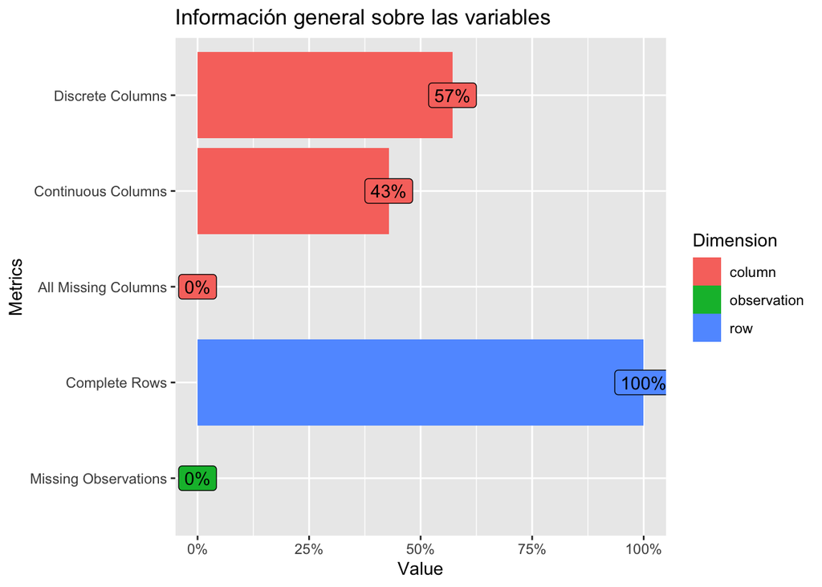

```r
plot_intro(vuelos3, title = "Información general sobre las variables")
```

Como se puede observar, la mayoría de las variables que hay en el dataset son de tipo discreto después de hacer la conversión de variables, en concreto el 57% de las variables.

Al trabajar con un conjunto de datos y analizarlo, lo ideal es que el dataset sea lo más completo posible y que no haya valores desconocidos o que estos sean mínimos, en mi caso esto se cumple a la perfección ya que todas las variables están completas y no falta ningún valor como se puede ver a continuación:

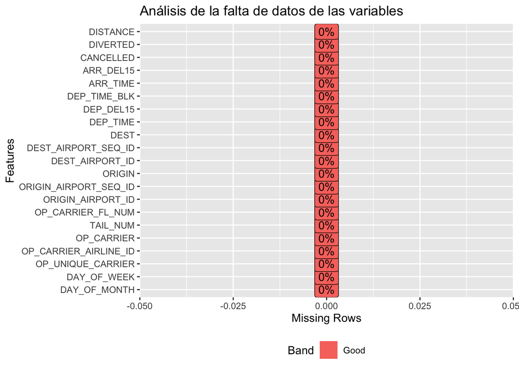

```r
plot_missing(vuelos3, title = "Análisis de la falta de datos de las variables")
```

Es interesante también analizar la normalidad de las variables del dataset:

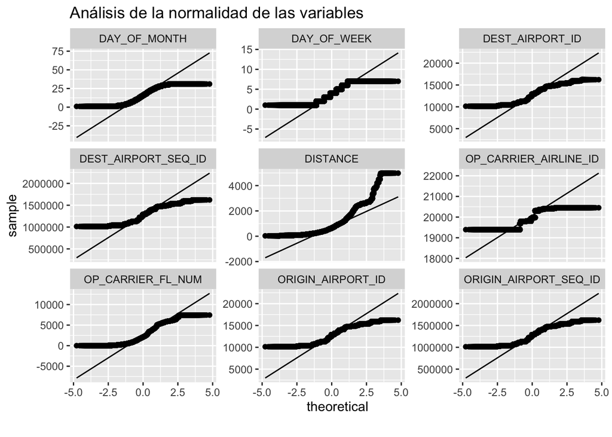

```r
plot_qq(vuelos3, title = "Análisis de la normalidad de las variables")
```

Ninguna variable sigue una distribución parecida a la normal ya que en todas aparece una cola a la derecha y otra a la izquierda.

## Exploración del dataset de aeropuertos

Es interesante ver dónde se encuentran los aeropuertos desde los que salen y a los que llegan los vuelos, ya que de esta manera se entiende mejor la distancia recorrida, la hora de salida y de llegada…

Antes de nada es necesario buscar el conjunto de datos con esta información, que se encuentra en el enlace de Kaggle: https://www.kaggle.com/usdot/flight-delays?select=airports.csv

Como siempre, hay que leer el fichero, que vuelve a ser un csv:

```r
aeropuertos = read_csv("Data/airports.csv")
```

Antes de hacer una representación hay que ver cómo son los datos y qué información útil podemos extraer de ellos.

```r
dim(aeropuertos)
```

```
## [1] 322   7
```

El número de observaciones del dataset es 322 y el número de variables es 7.

```r
str(aeropuertos)
```

```
## tibble [322 × 7] (S3: spec_tbl_df/tbl_df/tbl/data.frame)
##  $ IATA_CODE: chr [1:322] "ABE" "ABI" "ABQ" "ABR" ...
##  $ AIRPORT  : chr [1:322] "Lehigh Valley International Airport" "Abilene Regional Airport" "Albuquerque International Sunport" "Aberdeen Regional Airport" ...
##  $ CITY     : chr [1:322] "Allentown" "Abilene" "Albuquerque" "Aberdeen" ...
##  $ STATE    : chr [1:322] "PA" "TX" "NM" "SD" ...
##  $ COUNTRY  : chr [1:322] "USA" "USA" "USA" "USA" ...
##  $ LATITUDE : num [1:322] 40.7 32.4 35 45.4 31.5 ...
##  $ LONGITUDE: num [1:322] -75.4 -99.7 -106.6 -98.4 -84.2 ...
##  - attr(*, "spec")=
##   .. cols(
##   ..   IATA_CODE = col_character(),
##   ..   AIRPORT = col_character(),
##   ..   CITY = col_character(),
##   ..   STATE = col_character(),
##   ..   COUNTRY = col_character(),
##   ..   LATITUDE = col_double(),
##   ..   LONGITUDE = col_double()
##   .. )
```

```r
glimpse(aeropuertos)
```

```
## Rows: 322
## Columns: 7
## $ IATA_CODE <chr> "ABE", "ABI", "ABQ", "ABR", "ABY", "ACK", "ACT", "ACV", "AC…
## $ AIRPORT   <chr> "Lehigh Valley International Airport", "Abilene Regional Ai…
## $ CITY      <chr> "Allentown", "Abilene", "Albuquerque", "Aberdeen", "Albany"…
## $ STATE     <chr> "PA", "TX", "NM", "SD", "GA", "MA", "TX", "CA", "NJ", "AK",…
## $ COUNTRY   <chr> "USA", "USA", "USA", "USA", "USA", "USA", "USA", "USA", "US…
## $ LATITUDE  <dbl> 40.65236, 32.41132, 35.04022, 45.44906, 31.53552, 41.25305,…
## $ LONGITUDE <dbl> -75.44040, -99.68190, -106.60919, -98.42183, -84.19447, -70…
```

La mayoría de las variables son de tipo char excepto las variables que hacen referencia a la latitud y la longitud que son de tipo numérico.

Mediante summary vemos información adicional sobre cada una de las variables:

```r
summary(aeropuertos)
```

```
##   IATA_CODE           AIRPORT              CITY              STATE
##  Length:322         Length:322         Length:322         Length:322
##  Class :character   Class :character   Class :character   Class :character
##  Mode  :character   Mode  :character   Mode  :character   Mode  :character
##
##
##
##
##    COUNTRY             LATITUDE       LONGITUDE
##  Length:322         Min.   :13.48   Min.   :-176.65
##  Class :character   1st Qu.:33.65   1st Qu.:-110.84
##  Mode  :character   Median :39.30   Median : -93.40
##                     Mean   :38.98   Mean   : -98.38
##                     3rd Qu.:43.15   3rd Qu.: -82.72
##                     Max.   :71.29   Max.   : -64.80
##                     NA's   :3       NA's   :3
```

En este caso se puede entender bien lo que significa cada una de las variables, pero aun así se van a explicar para que no haya dudas:

- IATA_CODE: código formado por grupos de tres letras que designan a cada aeropuerto del mundo, son asignados por la Asociación Internacional de Transporte Aéreo.
- AIRPORT: indica el nombre de cada uno de los aeropuertos.
- CITY: hace referencia a la ciudad de Estados Unidos en la que se encuentra cada aeropuerto.
- STATE: hace referencia al estado de Estados Unidos donde se encuentra cada aeropuerto.
- COUNTRY: hace referencia al país en el que se encuentra cada aeropuerto, en este caso es siempre USA.
- LATITUDE: indica la latitud en la que se encuentra cada aeropuerto.
- LONGITUDE: indica la longitud en la que se encuentra cada aeropuerto.

Al conocer la latitud y la longitud de cada uno de los aeropuertos, la manera más rápida y mejor de representar los datos es mediante un mapa de Estados Unidos en el que se pueda ver la localización de los mismos.

Mediante la librería map se representa el mapa de Estados Unidos y después se añaden los puntos de cada uno de los aeropuertos:

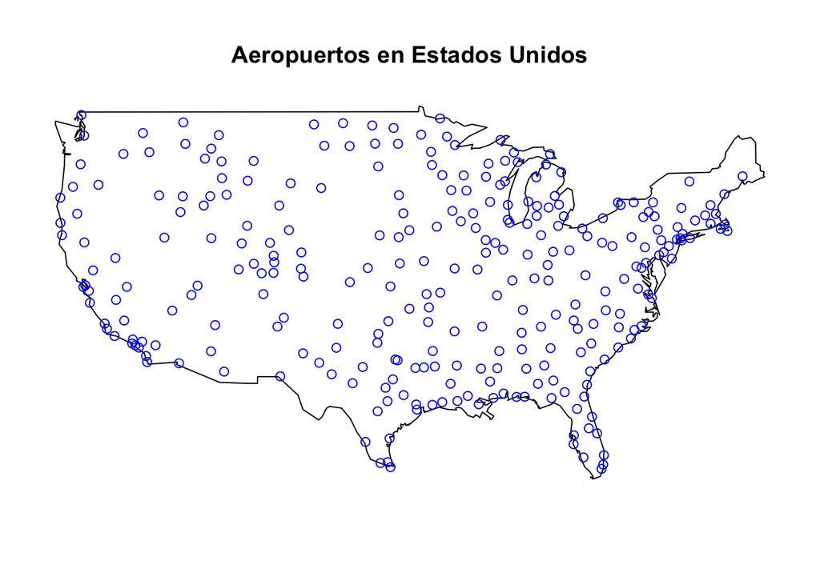

```r
{map('usa')
points(x = aeropuertos$LONGITUDE, y = aeropuertos$LATITUDE, col = "blue")
title(main = "Aeropuertos en Estados Unidos")}
```

Como en este mapa no se incluye Alaska, Hawái o Puerto Rico, se representa también el mapa del mundo para que se vean los aeropuertos que se encuentran en los lugares que no se ven en el mapa anterior:

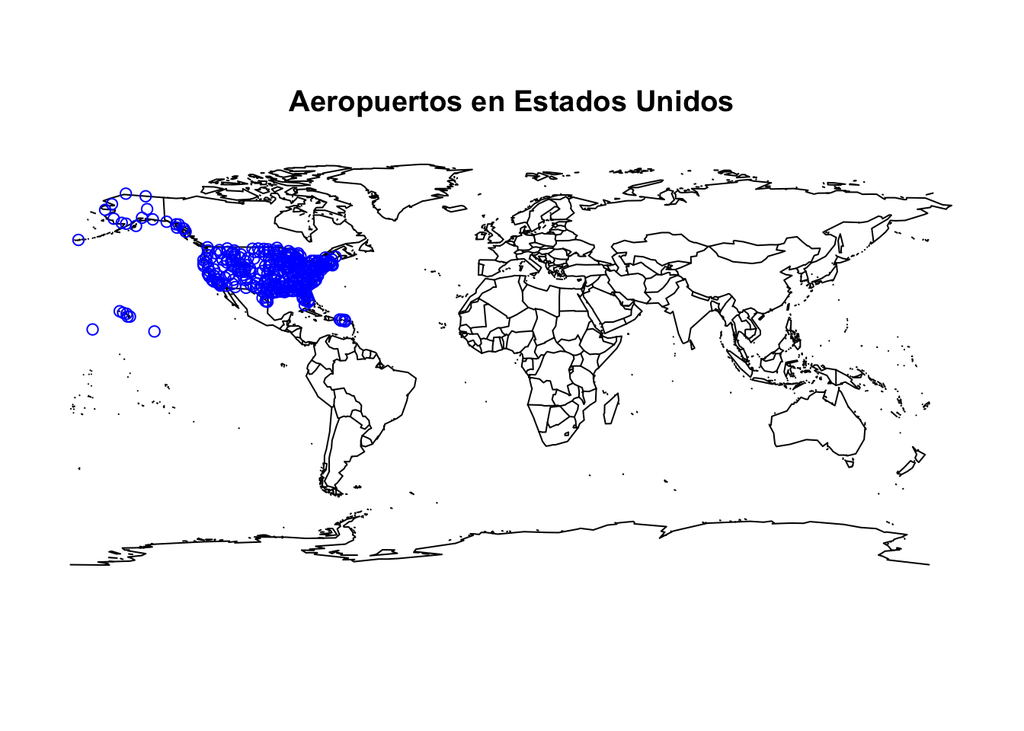

```r
{map('world')
points(x = aeropuertos$LONGITUDE, y = aeropuertos$LATITUDE, col = "blue")
title(main = "Aeropuertos en Estados Unidos")}
```

## Análisis de indidencias en los vuelos

Una vez que conocemos en detalle el conjunto de datos e incluso conocemos la localización de cada uno de los aeropuertos, se puede empezar a explorar con más profundidad el dataset y a obtener información interesante.

Lo primero que nos interesa conocer son los vuelos que se cancelaron, esta información se encuentra en la variable CANCELLED.

```r
summary(vuelos3$CANCELLED)
```

```
## Vuelo NO cancelado
##             565963
```

También es de interés comprobar si hubo algún vuelo que se desvió de su destino original, esta información se puede ver gracias a la variable DIVERTED.

```r
summary(vuelos3$DIVERTED)
```

```
## Vuelo NO desviado
##            565963
```

Estos resultados eran los previstos ya que cuando se convirtió la variable a factor, todos las observaciones valían lo mismo, 0.

```r
summary(vuelos3$DEP_DEL15)
```

```
## Retraso salida menos 15 mins Retraso salida 15 mins o más
##                       467658                        98305
```

```r
summary(vuelos3$ARR_DEL15)
```

```
## Retraso llegada menos 15 mins Retraso llegada 15 mins o más
##                        460741                        105222
```

Si que hubo vuelos con retrasos, en concreto hubo más vuelos con retraso de llegada que de salida, esto se puede explicar debido a que hubo turbulencias o fenómenos climatológicos adversos durante el trayecto.

De manera gráfica se puede entender mejor la cantidad de vuelos con retraso y sin retraso:

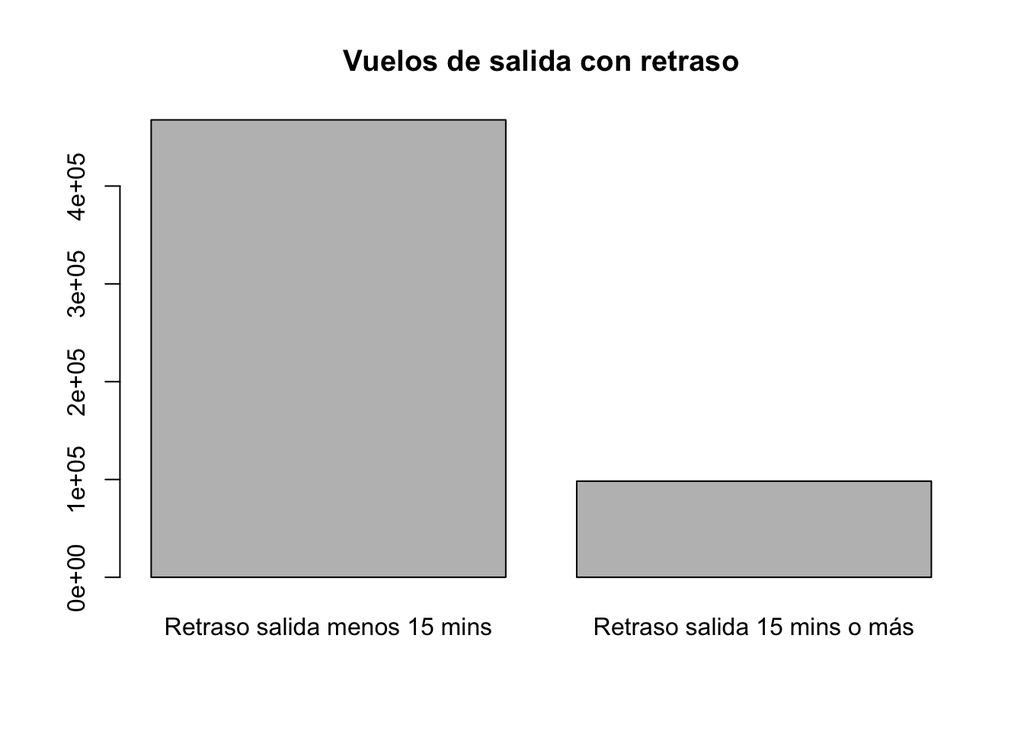

```r
plot(vuelos3$DEP_DEL15, main = "Vuelos de salida con retraso")
```

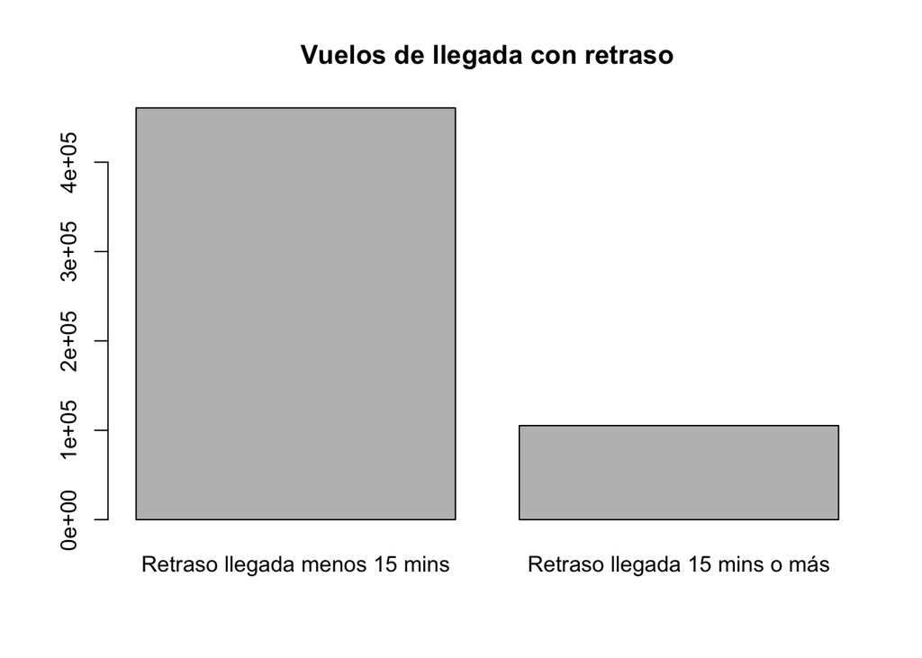

```r
plot(vuelos3$ARR_DEL15, main = "Vuelos de llegada con retraso")
```

Se calcula también el porcentaje de vuelos con retraso:

```r
prop.table(table(vuelos3$DEP_DEL15))
```

```
##
## Retraso salida menos 15 mins Retraso salida 15 mins o más
##                    0.8263049                    0.1736951
```

```r
addmargins(prop.table(table(vuelos3$DEP_DEL15)))
```

```
##
## Retraso salida menos 15 mins Retraso salida 15 mins o más
##                    0.8263049                    0.1736951
##                          Sum
##                    1.0000000
```

Un 17.37% de los vuelos realizados en enero salieron con 15 minutos o más de retraso.

```r
prop.table(table(vuelos3$ARR_DEL15))
```

```
##
## Retraso llegada menos 15 mins Retraso llegada 15 mins o más
##                     0.8140833                     0.1859167
```

```r
addmargins(prop.table(table(vuelos3$ARR_DEL15)))
```

```
##
## Retraso llegada menos 15 mins Retraso llegada 15 mins o más
##                     0.8140833                     0.1859167
##                           Sum
##                     1.0000000
```

Mientras que un 18.59% de los vuelos llegaron con retraso a su destino.

Ahora se van a analizar las posibles causas de estos retrasos, para ello se va a obtener qué aeropuertos son los que acumulan más retrasos.

Los retrasos de salida de cada uno de los aeropuertos son:

```r
aeropuertos_retrasos_salida = vuelos3 %>%
  filter(DEP_DEL15 == "Retraso salida 15 mins o más") %>%
  group_by(ORIGIN) %>%
  count(DEP_DEL15)
aeropuertos_retrasos_salida
```

```
## # A tibble: 345 x 3
## # Groups:   ORIGIN [345]
##    ORIGIN DEP_DEL15                        n
##    <chr>  <fct>                        <int>
##  1 ABE    Retraso salida 15 mins o más    49
##  2 ABI    Retraso salida 15 mins o más    24
##  3 ABQ    Retraso salida 15 mins o más   194
##  4 ABR    Retraso salida 15 mins o más     7
##  5 ABY    Retraso salida 15 mins o más    10
##  6 ACT    Retraso salida 15 mins o más     8
##  7 ACV    Retraso salida 15 mins o más    38
##  8 ACY    Retraso salida 15 mins o más    18
##  9 ADK    Retraso salida 15 mins o más     2
## 10 ADQ    Retraso salida 15 mins o más     9
## # … with 335 more rows
```

Seleccionamos el aeropuerto con mayor número de vuelos que despegan con un retraso de 15 minutos o más:

```r
aeropuertos_retrasos_salida %>% filter(n == max(aeropuertos_retrasos_salida$n))
```

```
## # A tibble: 1 x 3
## # Groups:   ORIGIN [1]
##   ORIGIN DEP_DEL15                        n
##   <chr>  <fct>                        <int>
## 1 ORD    Retraso salida 15 mins o más  6560
```

El aeropuerto internacional de Chicago-O’Hare (ORD), en la ciudad de Chicago, es el aeropuerto que acumula un mayor número de vuelos con retraso en su salida, un total de 6560 vuelos. Este aeropuerto es uno de los mayores del país y de los que tienen mayor tráfico de pasajeros.

```r
aeropuertos_retrasos_salida %>% filter(n == min(aeropuertos_retrasos_salida$n))
```

```
## # A tibble: 2 x 3
## # Groups:   ORIGIN [2]
##   ORIGIN DEP_DEL15                        n
##   <chr>  <fct>                        <int>
## 1 ELM    Retraso salida 15 mins o más     1
## 2 SWO    Retraso salida 15 mins o más     1
```

Mientras que los aeropuertos regionales de Elmira/Corning (ELM) en Nueva York y de Stillwater (SWO) en Oklahoma son los aeropuertos de los que despegan menos vuelos con retraso, únicamente un vuelo cada uno.

Hacemos lo mismo pero con los retrasos en las llegadas:

```r
aeropuertos_retrasos_llegada = vuelos3 %>%
  filter(ARR_DEL15 == "Retraso llegada 15 mins o más") %>%
  group_by(ORIGIN) %>%
  count(ARR_DEL15)
aeropuertos_retrasos_llegada
```

```
## # A tibble: 344 x 3
## # Groups:   ORIGIN [344]
##    ORIGIN ARR_DEL15                         n
##    <chr>  <fct>                         <int>
##  1 ABE    Retraso llegada 15 mins o más    65
##  2 ABI    Retraso llegada 15 mins o más    32
##  3 ABQ    Retraso llegada 15 mins o más   217
##  4 ABR    Retraso llegada 15 mins o más     8
##  5 ABY    Retraso llegada 15 mins o más     7
##  6 ACT    Retraso llegada 15 mins o más     7
##  7 ACV    Retraso llegada 15 mins o más    49
##  8 ACY    Retraso llegada 15 mins o más    33
##  9 ADK    Retraso llegada 15 mins o más     1
## 10 ADQ    Retraso llegada 15 mins o más     9
## # … with 334 more rows
```

Como antes, primero calculamos el aeropuerto con mayor cantidad de vuelos que llegan con retraso:

```r
aeropuertos_retrasos_llegada %>% filter(n == max(aeropuertos_retrasos_llegada$n))
```

```
## # A tibble: 1 x 3
## # Groups:   ORIGIN [1]
##   ORIGIN ARR_DEL15                         n
##   <chr>  <fct>                         <int>
## 1 ORD    Retraso llegada 15 mins o más  7655
```

```r
aeropuertos_retrasos_llegada %>% filter(n == min(aeropuertos_retrasos_llegada$n))
```

```
## # A tibble: 2 x 3
## # Groups:   ORIGIN [2]
##   ORIGIN ARR_DEL15                         n
##   <chr>  <fct>                         <int>
## 1 ADK    Retraso llegada 15 mins o más     1
## 2 CPR    Retraso llegada 15 mins o más     1
```

Claramente se puede ver que que los aeropuertos grandes acumulan más retrasos que los aeropuertos regionales, al tener que operar estos una mayor cantidad de vuelos y tener mayor afluencia de pasajeros. Otra posible razón de que el aeropuerto de Chicago sea el que acumula una mayor cantidad de retrasos es que dicha ciudad se caracteriza por su mal tiempo, lo que puede complicar considerablemente el correcto funcionamiento del mismo, especialmente en invierno, justo de cuando son los datos que estamos analizando.

La localización del aeropuerto de Chicago-O’Hare es:

```r
aeropuerto_mas_retrasos <- aeropuertos %>%
  filter(IATA_CODE == "ORD")
aeropuerto_mas_retrasos
```

```
## # A tibble: 1 x 7
##   IATA_CODE AIRPORT                      CITY   STATE COUNTRY LATITUDE LONGITUDE
##   <chr>     <chr>                        <chr>  <chr> <chr>      <dbl>     <dbl>
## 1 ORD       Chicago O'Hare Internationa… Chica… IL    USA         42.0     -87.9
```

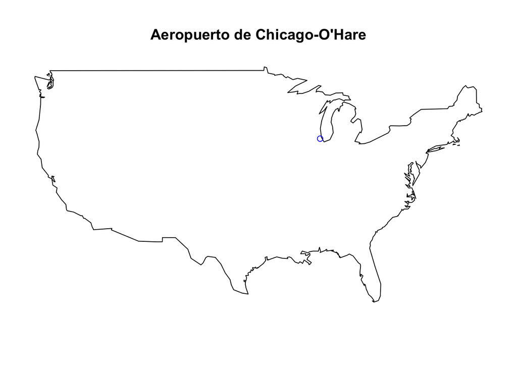

```r
{map('usa')
points(x = aeropuerto_mas_retrasos$LONGITUDE, y = aeropuerto_mas_retrasos$LATITUDE, col = "blue")
title(main = "Aeropuerto de Chicago-O'Hare")}
```

Al igual que se ha hecho con los aeropuertos, se va a analizar qué aerolíneas son las que acumulan más retrasos, ya que se tiende a pensar que las aerolíneas de bajo costo funcionan peor que las normales y por eso suelen ser menos puntuales.

Comenzamos con los vuelos con retraso en la salida:

```r
aerolineas_retrasos_salida = vuelos3 %>%
  filter(DEP_DEL15 == "Retraso salida 15 mins o más") %>%
  group_by(OP_CARRIER) %>%
  count(DEP_DEL15)
aerolineas_retrasos_salida
```

```
## # A tibble: 17 x 3
## # Groups:   OP_CARRIER [17]
##    OP_CARRIER DEP_DEL15                        n
##    <chr>      <fct>                        <int>
##  1 9E         Retraso salida 15 mins o más  3729
##  2 AA         Retraso salida 15 mins o más 11993
##  3 AS         Retraso salida 15 mins o más  2732
##  4 B6         Retraso salida 15 mins o más  6321
##  5 DL         Retraso salida 15 mins o más  9413
##  6 EV         Retraso salida 15 mins o más  2509
##  7 F9         Retraso salida 15 mins o más  2330
##  8 G4         Retraso salida 15 mins o más  1435
##  9 HA         Retraso salida 15 mins o más   585
## 10 MQ         Retraso salida 15 mins o más  4694
## 11 NK         Retraso salida 15 mins o más  2167
## 12 OH         Retraso salida 15 mins o más  3301
## 13 OO         Retraso salida 15 mins o más 12580
## 14 UA         Retraso salida 15 mins o más  8358
## 15 WN         Retraso salida 15 mins o más 18466
## 16 YV         Retraso salida 15 mins o más  2902
## 17 YX         Retraso salida 15 mins o más  4790
```

Al ser el número de aerolíneas considerablemnte inferior al de aeropuertos, se puede representar gráficamente el resultado:

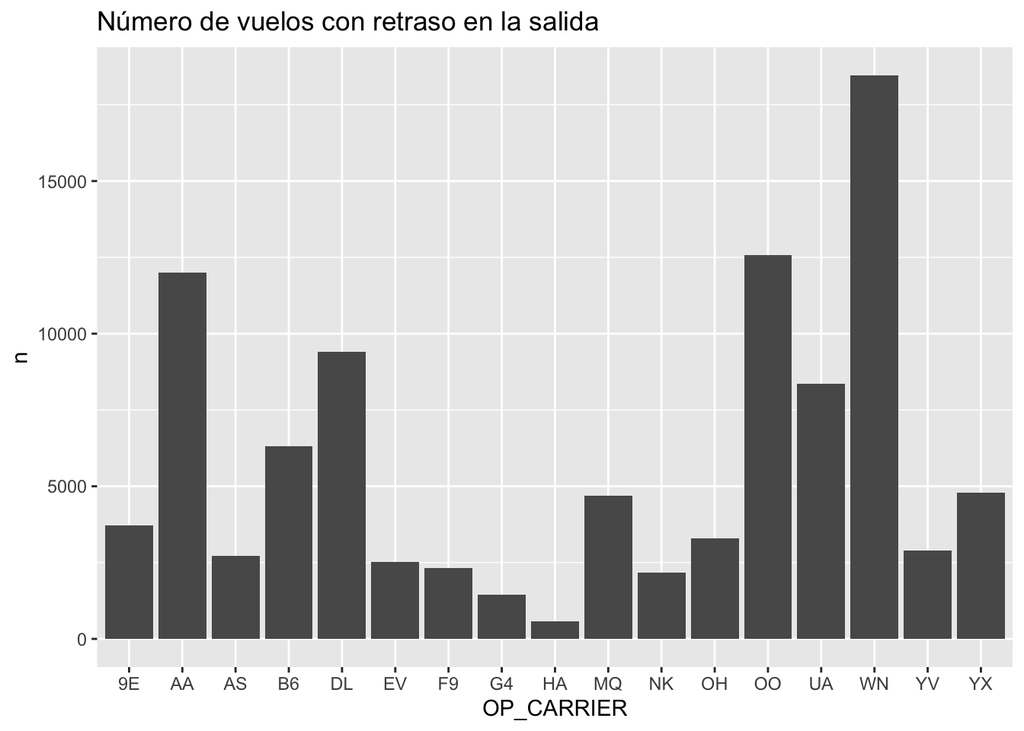

```r
ggplot(aerolineas_retrasos_salida) + geom_col(aes(x = OP_CARRIER, y = n)) + ggtitle("Número de vuelos con retraso en la salida")
```

```r
aerolineas_retrasos_salida %>% filter(n == max(aerolineas_retrasos_salida$n))
```

```
## # A tibble: 1 x 3
## # Groups:   OP_CARRIER [1]
##   OP_CARRIER DEP_DEL15                        n
##   <chr>      <fct>                        <int>
## 1 WN         Retraso salida 15 mins o más 18466
```

```r
aerolineas_retrasos_salida %>% filter(n == min(aerolineas_retrasos_salida$n))
```

```
## # A tibble: 1 x 3
## # Groups:   OP_CARRIER [1]
##   OP_CARRIER DEP_DEL15                        n
##   <chr>      <fct>                        <int>
## 1 HA         Retraso salida 15 mins o más   585
```

Claramente se puede ver que la aerolínea Southwest Airlines Co. (WN) es la que acumula un mayor número de vuelos que despegan con retraso, en concreto 18466 vuelos, mientras que la aerolínea Hawaiian Airlines Inc. (HA) es la que menos, únicamente 585 vuelos con retraso en la salida.

Se repite el proceso pero ahora con los retrasos en las llegadas:

```r
aerolineas_retrasos_llegada = vuelos3 %>%
  filter(ARR_DEL15 == "Retraso llegada 15 mins o más") %>%
  group_by(OP_CARRIER) %>%
  count(ARR_DEL15)
aerolineas_retrasos_llegada
```

```
## # A tibble: 17 x 3
## # Groups:   OP_CARRIER [17]
##    OP_CARRIER ARR_DEL15                         n
##    <chr>      <fct>                         <int>
##  1 9E         Retraso llegada 15 mins o más  4013
##  2 AA         Retraso llegada 15 mins o más 13741
##  3 AS         Retraso llegada 15 mins o más  3506
##  4 B6         Retraso llegada 15 mins o más  6429
##  5 DL         Retraso llegada 15 mins o más  9403
##  6 EV         Retraso llegada 15 mins o más  3022
##  7 F9         Retraso llegada 15 mins o más  2362
##  8 G4         Retraso llegada 15 mins o más  1728
##  9 HA         Retraso llegada 15 mins o más   851
## 10 MQ         Retraso llegada 15 mins o más  5844
## 11 NK         Retraso llegada 15 mins o más  2383
## 12 OH         Retraso llegada 15 mins o más  3475
## 13 OO         Retraso llegada 15 mins o más 14024
## 14 UA         Retraso llegada 15 mins o más  9156
## 15 WN         Retraso llegada 15 mins o más 16111
## 16 YV         Retraso llegada 15 mins o más  3310
## 17 YX         Retraso llegada 15 mins o más  5864
```

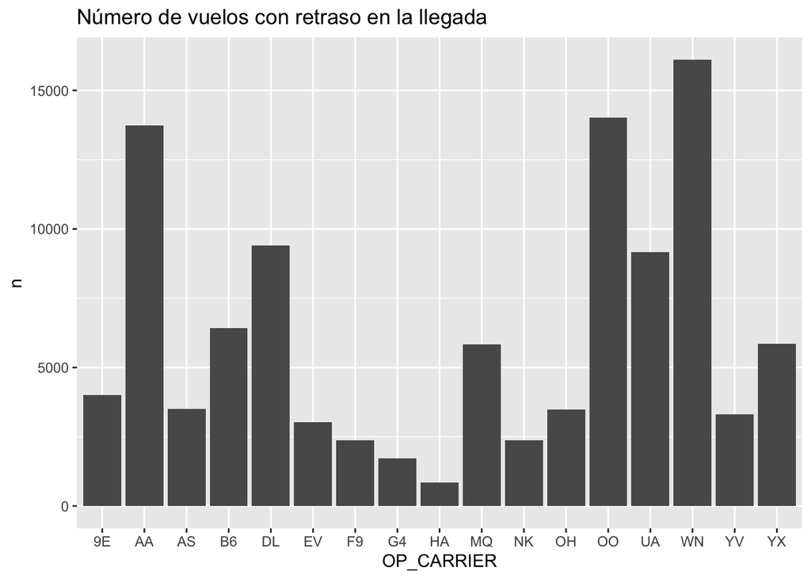

```r
ggplot(aerolineas_retrasos_llegada) + geom_col(aes(x = OP_CARRIER, y = n)) + ggtitle("Número de vuelos con retraso en la llegada")
```

```r
aerolineas_retrasos_llegada %>% filter(n == max(aerolineas_retrasos_llegada$n))
```

```
## # A tibble: 1 x 3
## # Groups:   OP_CARRIER [1]
##   OP_CARRIER ARR_DEL15                         n
##   <chr>      <fct>                         <int>
## 1 WN         Retraso llegada 15 mins o más 16111
```

```r
aerolineas_retrasos_llegada %>% filter(n == min(aerolineas_retrasos_llegada$n))
```

```
## # A tibble: 1 x 3
## # Groups:   OP_CARRIER [1]
##   OP_CARRIER ARR_DEL15                         n
##   <chr>      <fct>                         <int>
## 1 HA         Retraso llegada 15 mins o más   851
```

Se repiten los mismos resultados que se obtuvieron con los retrasos en el despegue, la aerolínea Southwest Airlines Co. (WN) es la que acumula mayor cantidad de vuelos con retraso a la hora de aterrizar, 16111 vuelos, mientras que la aerolínea Hawaiian Airlines Inc. (HA) es la que menos, solo 851 vuelos.

Teniendo en cuenta que Southwest Airlines Co. es la mayor aerolínea bajo costo de Estados Unidos y del mundo, y es la que transporta una mayor cantidad de pasajeros en el país, se entiende que esta sea la que acumula una mayor cantidad de retrasos.

## Análisis de la distancia de los vuelos

Una medida que proporciona información muy valiosa es la distancia recorrida por cada uno de los vuelos, ya que permite conocer en qué radio funcionan.

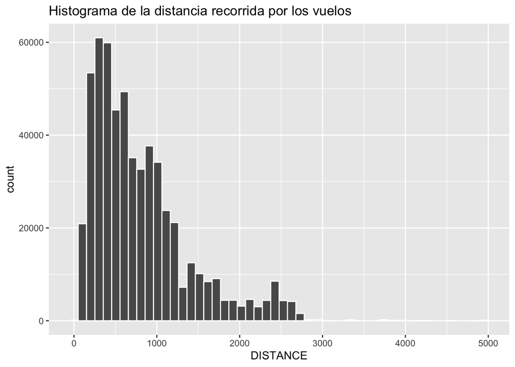

```r
ggplot(vuelos3) + geom_histogram(aes(x = DISTANCE), bins = 50, colour = "white") + ggtitle("Histograma de la distancia recorrida por los vuelos")
```

La mayoría de los vuelos recorrieron una distanca de entre 0 y 1000 millas, unos 1609 km. Aunque parezca una distancia considerable, teniendo en cuenta el tamaño de Estados Unidos, no lo es tanto, ya que la distancia entre la costa este y la costa oeste es de aproximadamente 2500 millas de media.

Por lo que viendo el resultado, se podría decir que la mayoría de los vuelos que se hicieron fueron de medio radio.

Como curiosidad, se va a analizar cuál ha sido el vuelo más corto que se ha realizado y cuál el más largo.

```r
max(vuelos3$DISTANCE)
```

```
## [1] 4983
```

```r
vuelos3 %>% filter(DISTANCE == 4983)
```

```
## # A tibble: 65 x 21
##    DAY_OF_MONTH DAY_OF_WEEK OP_UNIQUE_CARRI… OP_CARRIER_AIRL… OP_CARRIER
##           <dbl>       <dbl> <chr>                       <dbl> <chr>
##  1            1           2 HA                          19690 HA
##  2            1           2 HA                          19690 HA
##  3            1           2 DL                          19790 DL
##  4            1           2 DL                          19790 DL
##  5            2           3 DL                          19790 DL
##  6            2           3 DL                          19790 DL
##  7            2           3 HA                          19690 HA
##  8            2           3 HA                          19690 HA
##  9            3           4 HA                          19690 HA
## 10            3           4 HA                          19690 HA
## # … with 55 more rows, and 16 more variables: TAIL_NUM <chr>,
## #   OP_CARRIER_FL_NUM <dbl>, ORIGIN_AIRPORT_ID <dbl>,
## #   ORIGIN_AIRPORT_SEQ_ID <dbl>, ORIGIN <chr>, DEST_AIRPORT_ID <dbl>,
## #   DEST_AIRPORT_SEQ_ID <dbl>, DEST <chr>, DEP_TIME <chr>, DEP_DEL15 <fct>,
## #   DEP_TIME_BLK <chr>, ARR_TIME <chr>, ARR_DEL15 <fct>, CANCELLED <fct>,
## #   DIVERTED <fct>, DISTANCE <dbl>
```

Los vuelos que han recorrido una distancia mayor han sido los que se realizaron entre el aeropuerto internacional John F. Kennedy (JFK) de Nueva York y el aeropuerto internacional Daniel K. Inouye (HNL) de Honolulu, Hawái o viceversa. Estos vuelos recorrieron una distancia de 4983 millas, casi 8020 km.

A continuación, se representa de manera gráfica la distancia entre los dos aeropuertos mencionados:

```r
aeropuertos_distancia_maxima <- aeropuertos %>%
  filter(IATA_CODE == "JFK" | IATA_CODE == "HNL")
aeropuertos_distancia_maxima
```

```
## # A tibble: 2 x 7
##   IATA_CODE AIRPORT                      CITY   STATE COUNTRY LATITUDE LONGITUDE
##   <chr>     <chr>                        <chr>  <chr> <chr>      <dbl>     <dbl>
## 1 HNL       Honolulu International Airp… Honol… HI    USA         21.3    -158.
## 2 JFK       John F. Kennedy Internation… New Y… NY    USA         40.6     -73.8
```

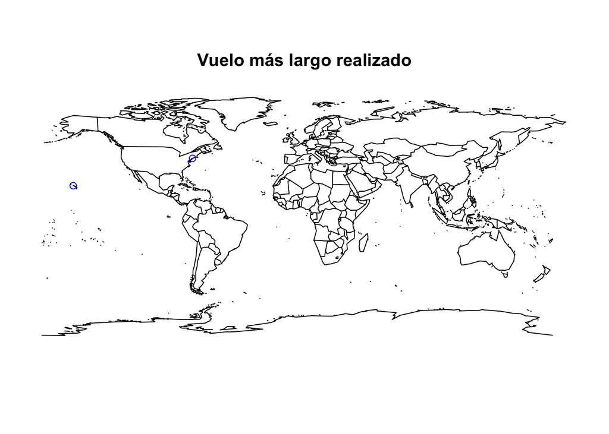

```r
{map('world')
points(x = aeropuertos_distancia_maxima$LONGITUDE, y = aeropuertos_distancia_maxima$LATITUDE, col = "blue")
title(main = "Vuelo más largo realizado")}
```

Ahora se pasa al vuelo con la distancia mínima:

```r
min(vuelos3$DISTANCE)
```

```
## [1] 31
```

```r
vuelos3 %>% filter(DISTANCE == 31)
```

```
## # A tibble: 54 x 21
##    DAY_OF_MONTH DAY_OF_WEEK OP_UNIQUE_CARRI… OP_CARRIER_AIRL… OP_CARRIER
##           <dbl>       <dbl> <chr>                       <dbl> <chr>
##  1            1           2 AS                          19930 AS
##  2            1           2 AS                          19930 AS
##  3            2           3 AS                          19930 AS
##  4            2           3 AS                          19930 AS
##  5            3           4 AS                          19930 AS
##  6            3           4 AS                          19930 AS
##  7            4           5 AS                          19930 AS
##  8            4           5 AS                          19930 AS
##  9            5           6 AS                          19930 AS
## 10            6           7 AS                          19930 AS
## # … with 44 more rows, and 16 more variables: TAIL_NUM <chr>,
## #   OP_CARRIER_FL_NUM <dbl>, ORIGIN_AIRPORT_ID <dbl>,
## #   ORIGIN_AIRPORT_SEQ_ID <dbl>, ORIGIN <chr>, DEST_AIRPORT_ID <dbl>,
## #   DEST_AIRPORT_SEQ_ID <dbl>, DEST <chr>, DEP_TIME <chr>, DEP_DEL15 <fct>,
## #   DEP_TIME_BLK <chr>, ARR_TIME <chr>, ARR_DEL15 <fct>, CANCELLED <fct>,
## #   DIVERTED <fct>, DISTANCE <dbl>
```

Los vuelos más cortos que se realizaron en enero de 2019 recorrieron 31 millas, menos de 50 km. Estos vuelos tuvieron como origen el aeropuerto Petersburg James A. Johnson (PSG), situado en Alaska, y como destino el aeropuerto Wrangell Airport (WRG), también en Alaska.

Siendo la representación gráfica de la localización de los aeropuertos:

```r
aeropuertos_distancia_minima <- aeropuertos %>%
  filter(IATA_CODE == "PSG" | IATA_CODE == "WRG")
aeropuertos_distancia_minima
```

```
## # A tibble: 2 x 7
##   IATA_CODE AIRPORT                    CITY     STATE COUNTRY LATITUDE LONGITUDE
##   <chr>     <chr>                      <chr>    <chr> <chr>      <dbl>     <dbl>
## 1 PSG       Petersburg James A. Johns… Petersb… AK    USA         56.8     -133.
## 2 WRG       Wrangell Airport           Wrangell AK    USA         56.5     -132.
```

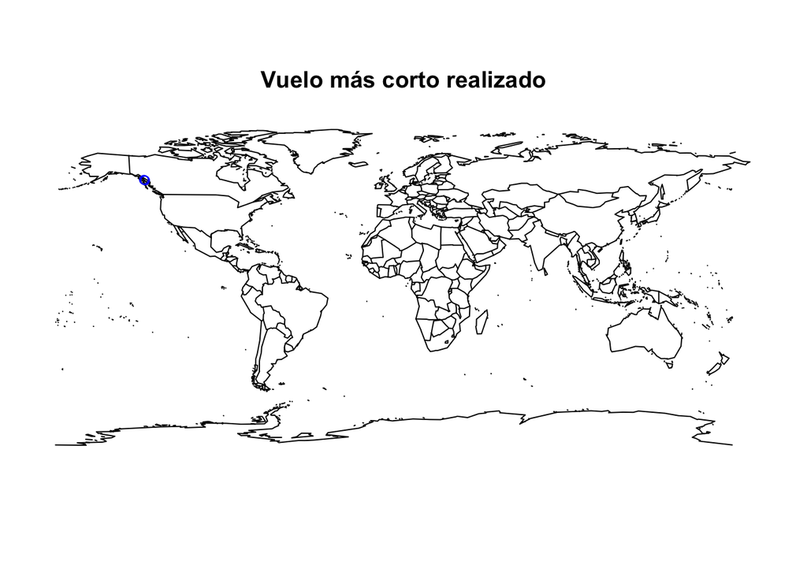

```r
{map('world')
points(x = aeropuertos_distancia_minima$LONGITUDE, y = aeropuertos_distancia_minima$LATITUDE, col = "blue")
title(main = "Vuelo más corto realizado")}
```

También se van a analizar los valores atípicos en la distancia de los vuelos, para ello primero obtenemos la media y la mediana:

```r
summary(vuelos3$DISTANCE)
```

```
##    Min. 1st Qu.  Median    Mean 3rd Qu.    Max.
##    31.0   366.0   642.0   802.4  1045.0  4983.0
```

El valor de la media y la mediana difiere considerablemente, por lo que la media no se puede considerar representativa y lleva a pensar que esta se ha visto afectada por los valores atípicos y que por tanto efectivamente los hay.

Mediante un boxplot de la distancia podemos ver gráficamente si hay valores atípicos, dónde se encuentran y si hay muchos o pocos:

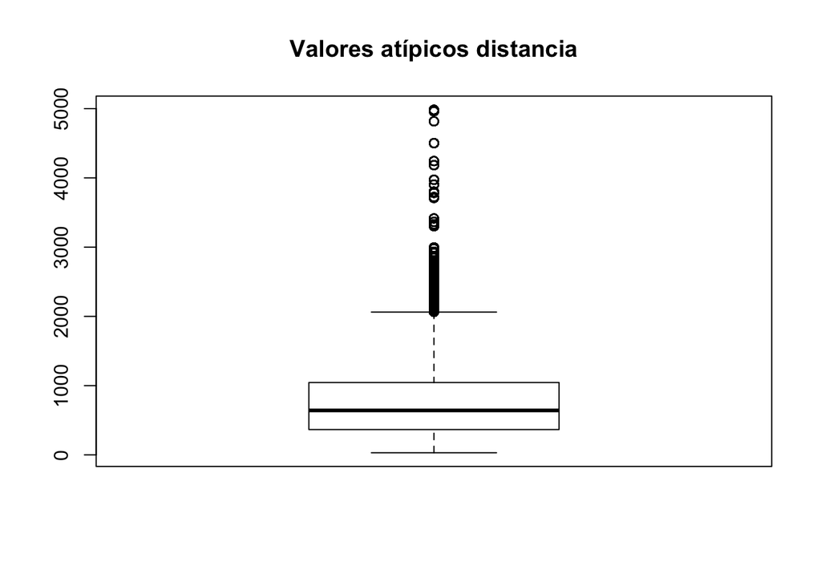

```r
bp = boxplot(vuelos3$DISTANCE, main="Valores atípicos distancia")
```

Se ven bastantes valores atípicos, estos se encuentran a la derecha (o arriba según aparece representado el boxplot).

El número de valores atípicos que hay se muestra a continuación:

```r
length(bp$out)
```

```
## [1] 32279
```

En total hay 32279 valores atípicos.

Las posiciones de estos en el dataset son las siguientes:

```r
which(vuelos3$DISTANCE %in% bp$out)
```

[output not shown]

[output cut: 3213 more lines]

## Análisis de los aeropuertos

Las variables de los aeropuertos de origen y destino de los vuelos nos permiten conocer cuáles son los aeropuertos que tienen un mayor tráfico y cuáles los que menos.

Primero analizamos los aeropuertos de origen de los vuelos:

```r
aeropuerto_trafico_origen = vuelos3 %>% count(ORIGIN)
aeropuerto_trafico_origen %>% filter(n == max(aeropuerto_trafico_origen$n))
```

```
## # A tibble: 1 x 2
##   ORIGIN     n
##   <chr>  <int>
## 1 ATL    30783
```

El aeropuerto del que sale un mayor número de vuelos es el aeropuerto internacional Hartsfield-Jackson o aeropuerto de Atlanta (ATL).

```r
aeropuerto_trafico_origen %>% filter(n == min(aeropuerto_trafico_origen$n))
```

```
## # A tibble: 1 x 2
##   ORIGIN     n
##   <chr>  <int>
## 1 OGD        8
```

Mientras que el aeropuerto del que sale un menor número de vuelos es el de Ogden-Hinckley (OGD), un aeropuerto de Utah del que solo salieron 8 vuelos en enero de 2019.

Se vuelve a hacer lo mismo pero con los aeropuertos de destino:

```r
aeropuerto_trafico_destino = vuelos3 %>% count(DEST)
aeropuerto_trafico_destino %>% filter(n == max(aeropuerto_trafico_destino$n))
```

```
## # A tibble: 1 x 2
##   DEST      n
##   <chr> <int>
## 1 ATL   30797
```

Al igual que sucedía con el aeropuerto de origen de los vuelos, el aeropuerto de Atlanta es el que tiene la mayor cantidad de vuelos con destino a él.

```r
aeropuerto_trafico_destino %>% filter(n == min(aeropuerto_trafico_destino$n))
```

```
## # A tibble: 1 x 2
##   DEST      n
##   <chr> <int>
## 1 OGD       8
```

Y lo mismo ocurre con el aeropuerto al que llegan menos vuelos, el aeropuerto de Ogden-Hinckley.

Los resultados obtenidos tienen sentido ya que el aeropuerto de Atlanta es el aeropuerto con mayor tráfico de Estados Unidos y del mundo.

La representación de la localización del aeropuerto de Atlanta es:

```r
aeropuerto_mas_transitado <- aeropuertos %>%
  filter(IATA_CODE == "ATL")
(aeropuerto_mas_transitado)
```

```
## # A tibble: 1 x 7
##   IATA_CODE AIRPORT                      CITY   STATE COUNTRY LATITUDE LONGITUDE
##   <chr>     <chr>                        <chr>  <chr> <chr>      <dbl>     <dbl>
## 1 ATL       Hartsfield-Jackson Atlanta … Atlan… GA    USA         33.6     -84.4
```

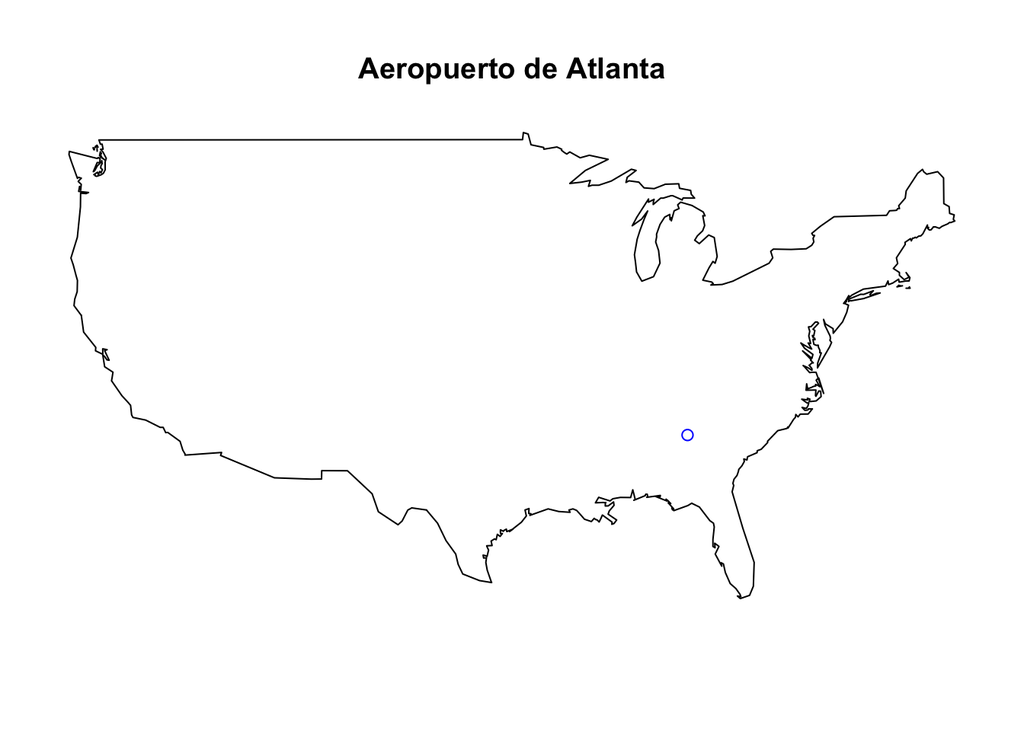

```r
{map('usa')
points(x = aeropuerto_mas_transitado$LONGITUDE, y = aeropuerto_mas_transitado$LATITUDE, col = "blue")
title(main = "Aeropuerto de Atlanta")}
```

## Análisis de las aerolíneas

Ya que el dataset contiene información de la aerolínea que ha operado el vuelo, podemos hacer un análisis de cuáles son las aerolíneas que realizaron un mayor número de vuelos, cuáles realizaron vuelos más cortos, cuáles realizaron vuelos más largos…

Lo primero es conocer las diferentes aerolíneas que operaron algún vuelo:

```r
vuelos_aerolinea = vuelos3 %>%
  count(OP_CARRIER)
(vuelos_aerolinea)
```

```
## # A tibble: 17 x 2
##    OP_CARRIER      n
##    <chr>       <int>
##  1 9E          19821
##  2 AA          75354
##  3 AS          20204
##  4 B6          23395
##  5 DL          73403
##  6 EV          12200
##  7 F9           9490
##  8 G4           6694
##  9 HA           6785
## 10 MQ          23710
## 11 NK          15009
## 12 OH          22369
## 13 OO          61770
## 14 UA          46126
## 15 WN         107235
## 16 YV          17829
## 17 YX          24569
```

En enero de 2019, 17 aerolíneas diferentes operaron algún vuelo con origen y destino en Estados Unidos.

```r
vuelos_aerolinea %>% filter(n == max(vuelos_aerolinea$n))
```

```
## # A tibble: 1 x 2
##   OP_CARRIER      n
##   <chr>       <int>
## 1 WN         107235
```

La aerolínea que realizó más vuelos fue la que tiene como código IATA: WN, que corresponde con Southwest Airlines Co. Esta es una aerolínea de bajo costo con sede en Dallas, Texas. Es la mayor aerolínea de Estados Unidos por número de pasajeros domésticos transportados al año, por lo que tiene sentido el resultado obtenido.

```r
vuelos_aerolinea %>% filter(n == min(vuelos_aerolinea$n))
```

```
## # A tibble: 1 x 2
##   OP_CARRIER     n
##   <chr>      <int>
## 1 G4          6694
```

La aerolínea Allegiant Air, con código IATA G4 es la que operó un menor número de vuelos. Esta es otra aerolínea de bajo costo con sede en Summerlin, Nevada.

Para comparar más fácilmente la magnitud de los resultados, se representan mediante un gráfico de barras:

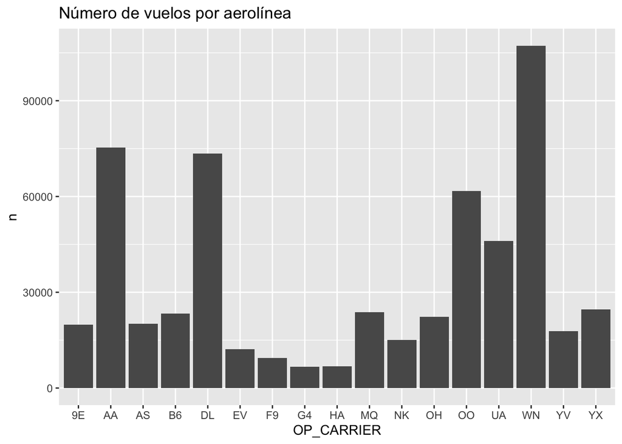

```r
ggplot(vuelos_aerolinea) + geom_col(mapping = aes(x = OP_CARRIER, y = n)) + ggtitle("Número de vuelos por aerolínea")
```

Se puede observar la gran diferencia en el número de vuelos operados por las 4 aerolíneas que operaron más vuelos en comparación con el resto de aerolíneas.

Otro dato interesante a analizar es qué aerolíneas son las que operan en corto radio y cuáles en largo radio.

```r
distancia_vuelos_aerolinea = vuelos3 %>%
  group_by(OP_CARRIER) %>%
  summarise(media = mean(DISTANCE))
(distancia_vuelos_aerolinea)
```

```
## # A tibble: 17 x 2
##    OP_CARRIER media
##    <chr>      <dbl>
##  1 9E          471.
##  2 AA          989.
##  3 AS         1323.
##  4 B6         1117.
##  5 DL          899.
##  6 EV          455.
##  7 F9         1068.
##  8 G4          909.
##  9 HA          738.
## 10 MQ          438.
## 11 NK         1018.
## 12 OH          387.
## 13 OO          501.
## 14 UA         1204.
## 15 WN          736.
## 16 YV          582.
## 17 YX          592.
```

```r
distancia_vuelos_aerolinea %>% filter(media == max(distancia_vuelos_aerolinea$media))
```

```
## # A tibble: 1 x 2
##   OP_CARRIER media
##   <chr>      <dbl>
## 1 AS         1323.
```

La aerolínea que ha operado los vuelos más largos es AS, Alaska Airlines Inc., con una media de 1323.463 millas por vuelo.

```r
distancia_vuelos_aerolinea %>% filter(media == min(distancia_vuelos_aerolinea$media))
```

```
## # A tibble: 1 x 2
##   OP_CARRIER media
##   <chr>      <dbl>
## 1 OH          387.
```

Mientras que la aerolínea PSA Airlines Inc., con código OH, es la que ha operado los vuelos con menor recorrido, 387.1068 millas de media.

En el siguiente gráfico se puede ver la relación entre la distancia recorrida por los vuelos operados por cada una de las aerolíneas:

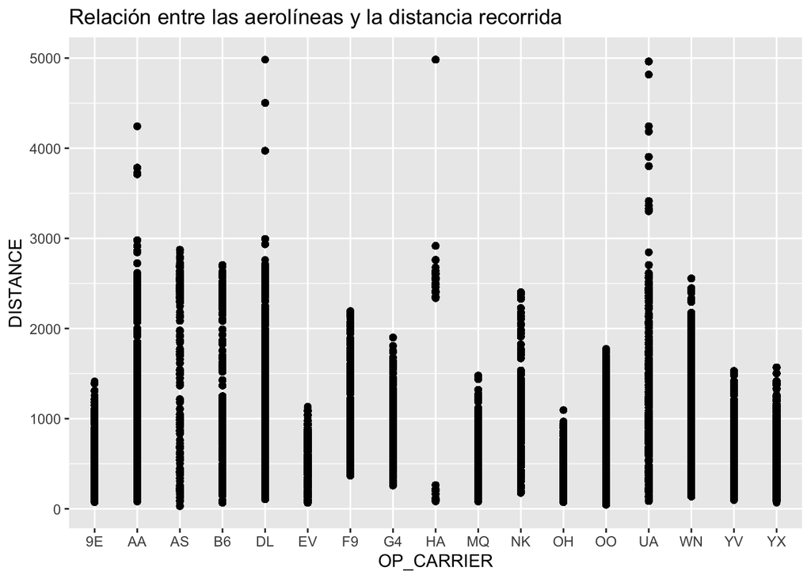

```r
ggplot(vuelos3) + geom_point(mapping = aes(x = OP_CARRIER, y = DISTANCE)) + ggtitle("Relación entre las aerolíneas y la distancia recorrida")
```

Además de lo comentado anteriormente sobre la aerolínea que opera los vuelos más cortos y más largos, otras aerolíneas que operan vuelos de corto radio son Envoy Air (MQ), ExpressJet Airlines LLC (EV) o Endeavor Air (9E), mientras que algunas de los que operan vuelos de largo radio son United Airlines Inc. (UA), JetBlue Airways (B6) o Frontier Airlines (F9).

## Análisis de los días

El análisis de los días de la semana y del mes en los que se produce un mayor número de vuelos es interesante para conocer qué días la gente viaja más.

El número de vuelos que se ha realizado cada día del mes de enero es:

```r
vuelos_dia = vuelos3 %>%
  count(DAY_OF_MONTH)
(vuelos_dia)
```

```
## # A tibble: 31 x 2
##    DAY_OF_MONTH     n
##           <dbl> <int>
##  1            1 17844
##  2            2 20170
##  3            3 19341
##  4            4 19467
##  5            5 16643
##  6            6 19096
##  7            7 19851
##  8            8 18579
##  9            9 19045
## 10           10 19756
## # … with 21 more rows
```

Si se representa el resultado mediante una gráfica, se obtiene:

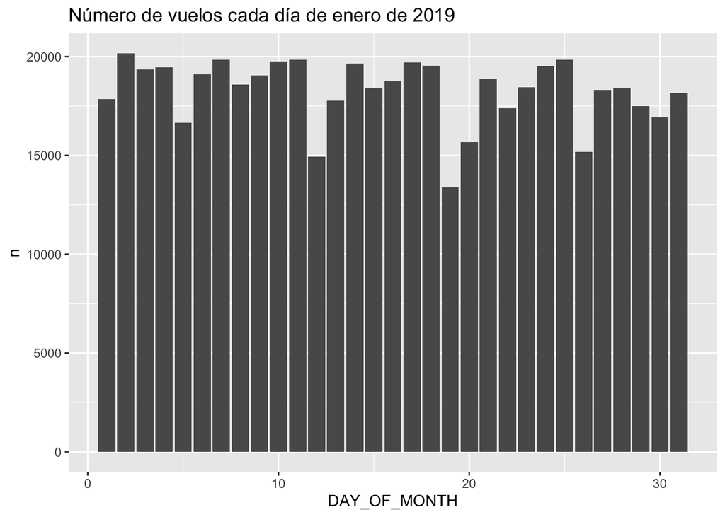

```r
ggplot(vuelos_dia) + geom_col(mapping = aes(x = DAY_OF_MONTH, y = n)) + ggtitle("Número de vuelos cada día de enero de 2019")
```

Donde se puede observar que el día 2 es el día en el que hubo mayor número de vuelos y el día 19 el que se realizaron menos.

Una vez que se ha comprobado gráficamente se va a calcular numéricamente para estar seguros de las conclusiones:

```r
vuelos_dia %>% filter(n == max(vuelos_dia$n))
```

```
## # A tibble: 1 x 2
##   DAY_OF_MONTH     n
##          <dbl> <int>
## 1            2 20170
```

Efectivamente el 2 de enero de 2019 el día en el que se produjo un mayor número de vuelos, en concreto 20170 vuelos.

```r
vuelos_dia %>% filter(n == min(vuelos_dia$n))
```

```
## # A tibble: 1 x 2
##   DAY_OF_MONTH     n
##          <dbl> <int>
## 1           19 13382
```

En cambio, el 19 de enero solo hubo 13382 vuelos, el día con menos vuelos realizados de todo el mes.

Sin analizar los datos, se puede pensar que el viernes o el fin de semana son los días que más vuelos se realizan al no tener la gente que trabajar, o por el controario, que entre semana hay más vuelos ya que mucha gente se desplaza por temas laborales. A continuación se va a analizar en qué días de la semana se realizan más vuelos.

```r
vuelos_semana = vuelos3 %>%
  count(DAY_OF_WEEK)
(vuelos_semana)
```

```
## # A tibble: 7 x 2
##   DAY_OF_WEEK     n
##         <dbl> <int>
## 1           1 76805
## 2           2 89682
## 3           3 93343
## 4           4 96473
## 5           5 78654
## 6           6 60146
## 7           7 70860
```

Viendo los resultados llama la atención que los días en los que se producen más vuelos son los miércoles y los jueves, mientras que los sábados son el día de la semana en el que se realizan menos vuelos. Esto se puede explicar porque normalmente las compañías aéreas suben los precios para viajar el viernes y los fin de semanas.

Mediante una representación gráfica de los datos obtenidos se puede ver mejor la comparación entre la cantidad de vuelos realizados cada día de la semana:

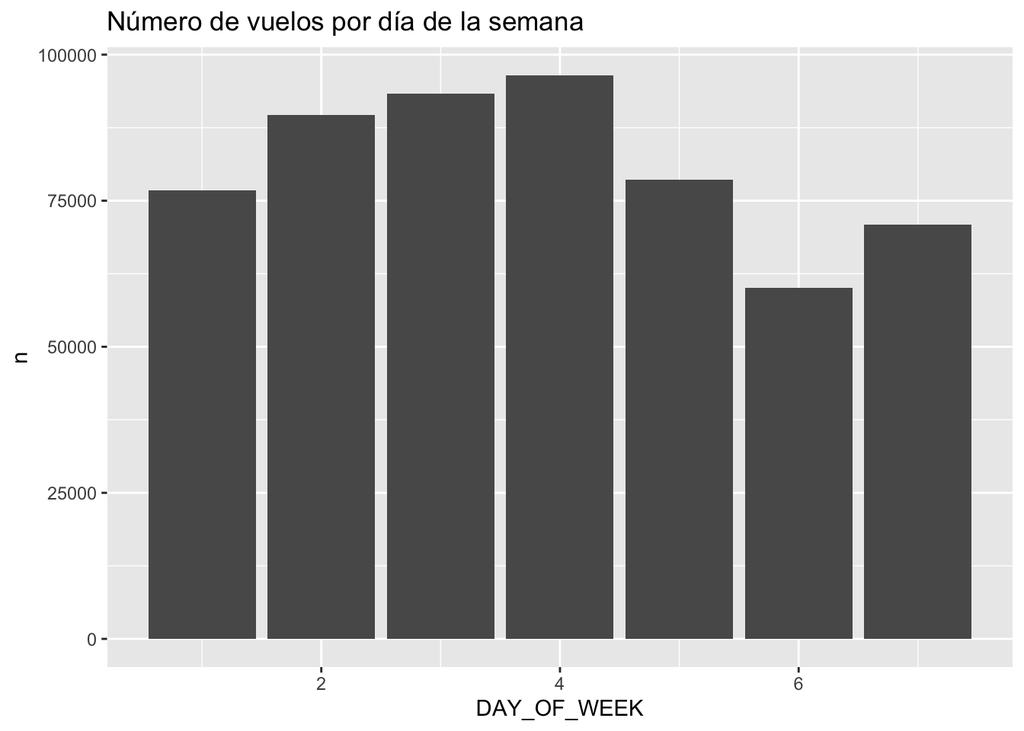

```r
ggplot(vuelos_semana) + geom_col(mapping = aes(x = DAY_OF_WEEK, y = n)) + ggtitle("Número de vuelos por día de la semana")
```

## Conclusión

Este análisis del dataset ha permitido entenderlo y conocerlo con más detalle, saber cuáles son los vuelos más largos y más cortos, qué aerolíneas operan en corto radio o largo radio, qué días del mes y de la semana se realizan más vuelos y las diferentes incidencias que ha habido, ya sea de retrasos, cancelaciones o desvíos.

En resumen, se ha conseguido entender mejor el sector aeronáutico de Estados Unidos y esto permite y facilita la toma de futuras decisiones, como por ejemplo la decisión de entrar o no a operar en dicho sector con una nueva compañía aeronáutica.